# R Notebook

# Análise de dados sobre Conspiração na pandemia de covid-19

```r
# loading libraries
library(here, quietly=T)
library(dplyr, quietly=T)
library(tidyr, quietly=T)
library(ggplot2, quietly=T)
library(janitor, quietly = T)
library(arm, quietly=T)
library(rstanarm, quietly=T)
library(bayesplot)
library(MASS)
```

```r
here()
```

```
## [1] "/home/mgaldino/Documentos/Pessoal/Neuroscience/Covid-19/neuro-covid-19"
```

# Causas de crença em conspiração

Uma breve revisão da literatura sugere que podemos agrupar os motivos para alguém acreditar em teorias da conspiração em: motivos epistêmicos, motivos existenciais e motivos sociais (Douglas et. al, 2017; Gligorić, 2021), ainda que a distinção entre esses três tipos de motivos não seja 100% clara. Os gráficos (DAGs) abaixo modelam as relações causais sugeridas para os três grupos de motivos:

# Motivos epistêmicos

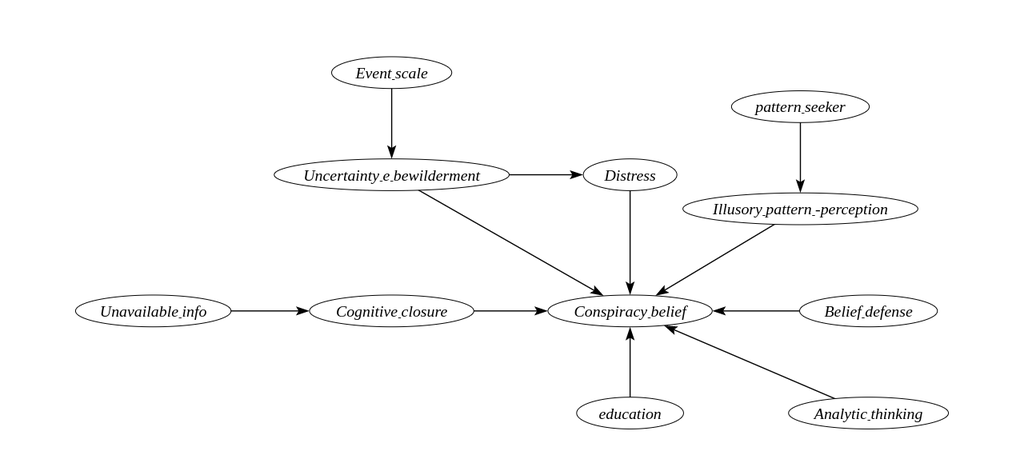

# Motivos Existenciais

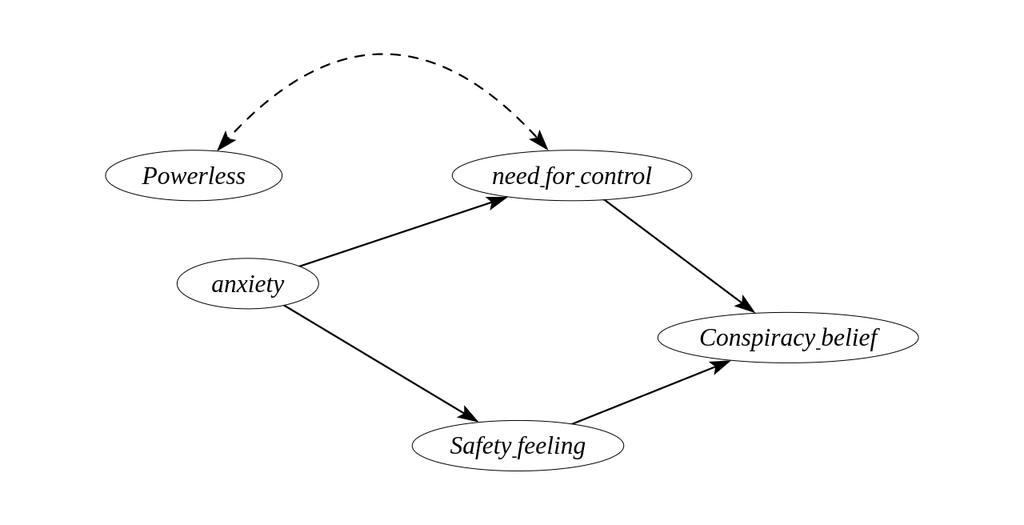

# Motivos Sociais

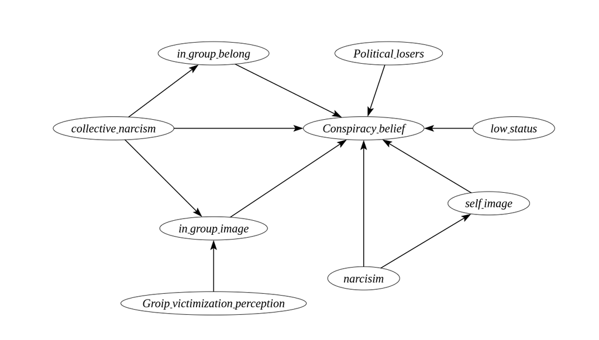

```r
# loading libraries
library(here)
library(dplyr)
library(ggplot2)
library(readxl)
library(janitor)
library(tidyr)
library(readr)
library(rstanarm)
library(forcats)
library(papeR)
library(sjPlot)
library(sjmisc)
here()
```

traço de narcisimo individual, narcisimo coletivo, pertencimento social

# Importandos dados do Brasil

```r
icsmp <- read_rds(paste(here(), "Dados", "icsmp_v2.rds", sep="/"))

icsmp_br <- icsmp %>%
  clean_names() %>%
  dplyr::filter(iso3 == "BRA")
```

Das variáveis mencionadas e que aparecem no gráfico, o estudo sobre a Covid-19 possui algumas delas:

1. Medidas de narcisismo coletivo (cnarg 1, 2 e 3) e individual (narc 1, 2, 3, 4, 5 e 6). A direção de causalidade esperada é: quanto maior o narcismo (coletivo e individual), maior a chance de acreditar em teoria da conspiração (motivos sociais).
2. Medidas de auto-estima (self_esteem) (motivos sociais)
3. De pertencimento social (sbelong 1, 2, 3 e 4) (motivo social)
4. Percepção de risco (motivo epistêmico)

Eu espero também que, em países como o Brasil, que pessoas mais de direita tendam a acreditam na conspiração relacionada à Covid-19. De maneira geral, esperamos que países em que líderes foram negacionistas gerem esse alinhamento ideológico, isto é: ideologia de líder negacionista causa ideologia da pessoa similar a do líder de apoiar conspirações.

Por fim, variáveis demográficas que impactem habilidades cognitivas podem ser relevantes, como educação. Aqui, vamos usar slf_ladder, que é o mais próximo disso, embora também capture status relativo, e status de emprego, employ_status1.

# Processando dados

```r
icsmp_br_analise <- icsmp_br %>%
  dplyr::select(ctheory1, ctheory2, ctheory3, ctheory4, age, employ_status1, slf_ladder, happy, political_ideology, sex1, sex2, nar_tra_avg, col_nar_avg, soc_bel_avg,
cnarc1:cnarc3, narc1:narc6, self_esteem, sbelong1, sbelong2, sbelong3, sbelong4 ) %>%
  mutate(sex1 = factor(sex1, levels = 1:3, labels = c("Male", "Female", "Other")),
         employ_status1 = factor(employ_status1, levels = 1:6, labels = c("Employed full-time", "Employed part-time",
                                                          "Unemployed/looking for work", "Student", "Retired", "Other")))

icsmp_br_analise <- icsmp_br_analise %>%
  drop_na(ctheory1)
```

# Análise Descritiva

Vamos agora fazer uma rápida análise descritiva dos dados, olhando inicialmente apenas o Brasil. Em momento posterior, iremos considerar todos os países.

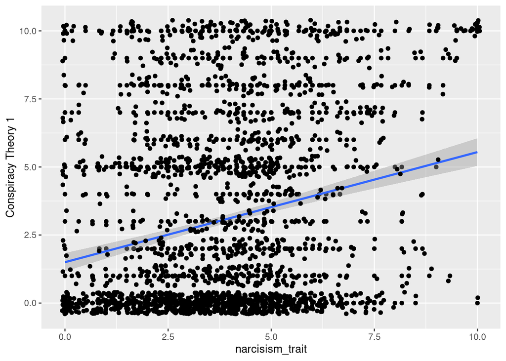

```r
icsmp_br_analise  %>%
  ggplot(aes(y=ctheory1, x=nar_tra_avg)) + geom_point() + geom_smooth(method= "lm") + geom_jitter() +
  ylab("Conspiracy Theory 1") + xlab("narcisism_trait")
```

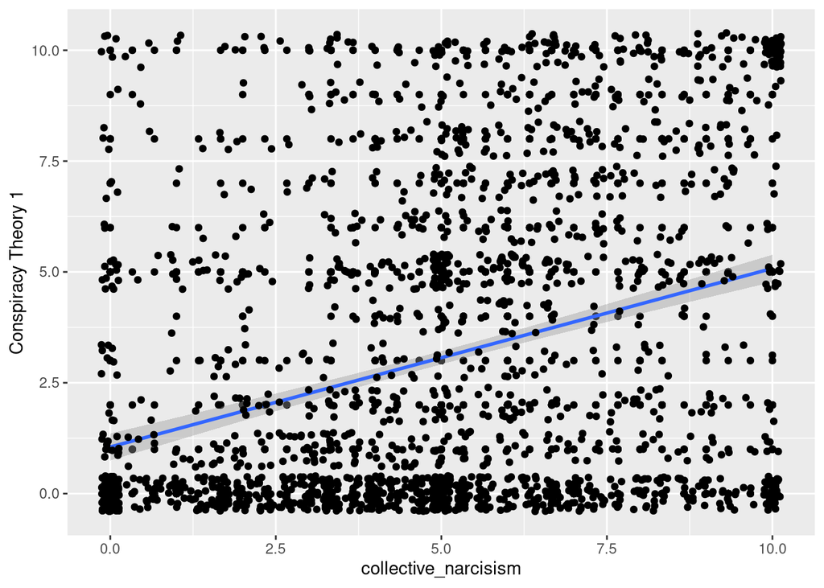

```r
icsmp_br_analise  %>%
  ggplot(aes(y=ctheory1, x=col_nar_avg)) + geom_point() + geom_smooth(method= "lm") +
  geom_jitter() +
  ylab("Conspiracy Theory 1") + xlab("collective_narcisism")
```

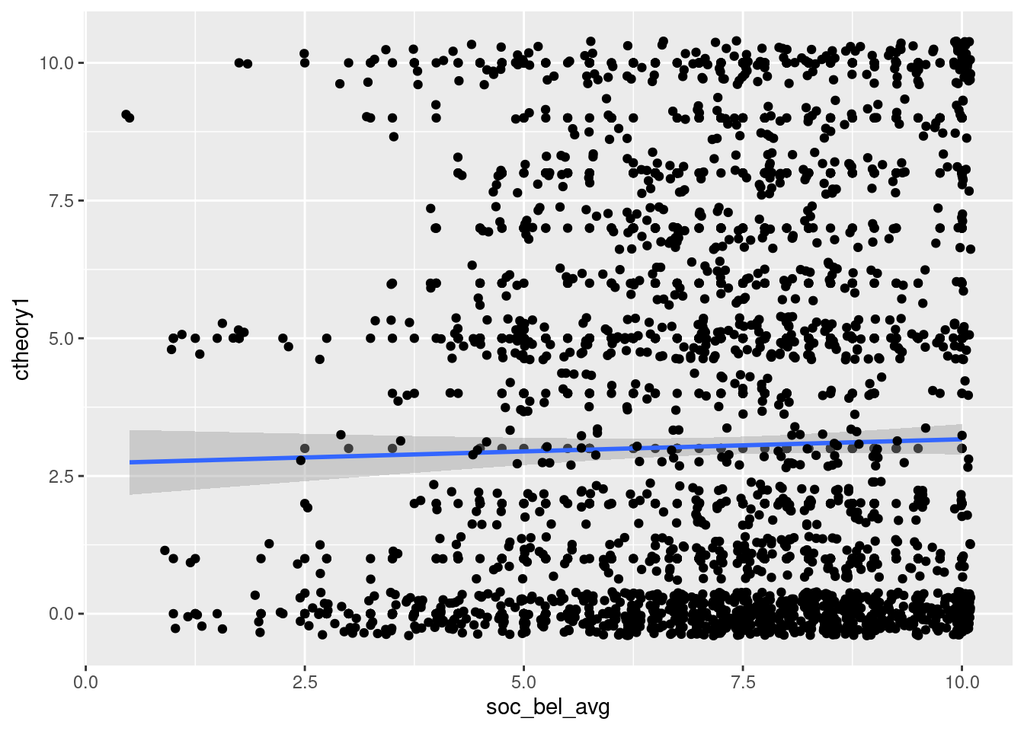

```r
icsmp_br_analise  %>%
  ggplot(aes(y=ctheory1, x=soc_bel_avg)) + geom_point() + geom_smooth(method= "lm") + geom_jitter()
```

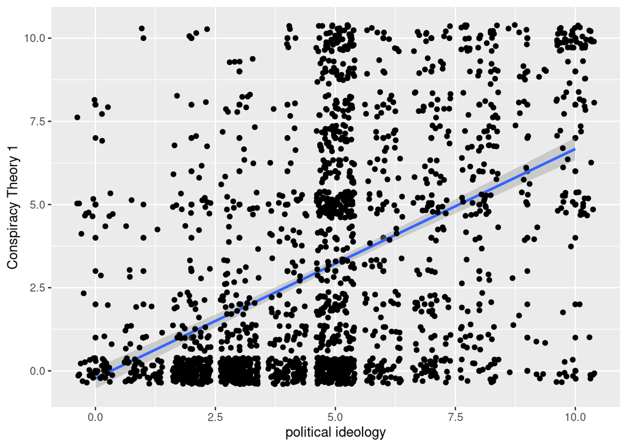

```r
icsmp_br_analise  %>%
  ggplot(aes(y=ctheory1, x=political_ideology)) + geom_point() + geom_smooth(method= "lm") +
  geom_jitter()  +
  ylab("Conspiracy Theory 1") + xlab("political ideology")
```

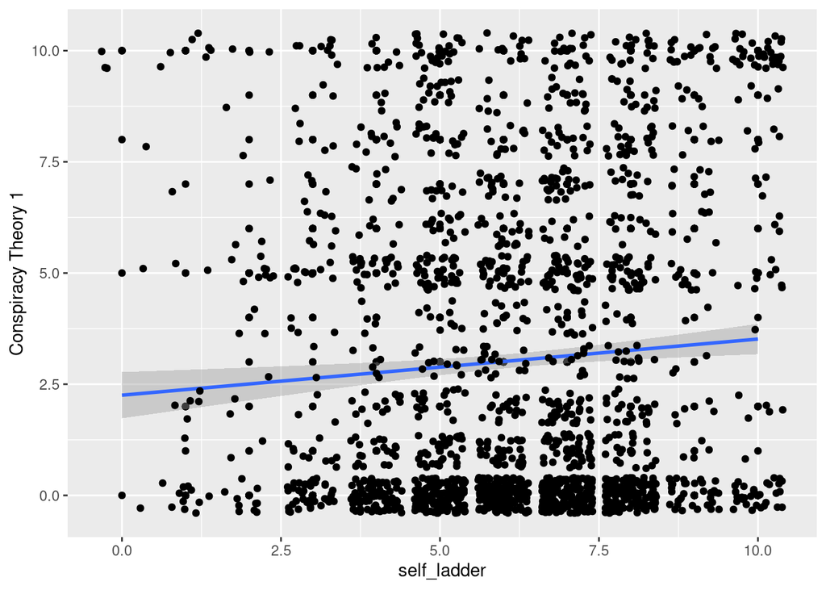

```r
icsmp_br_analise  %>%
  ggplot(aes(y=ctheory1, x=slf_ladder)) + geom_point() + geom_smooth(method= "lm") +
  geom_jitter()  +
  ylab("Conspiracy Theory 1") + xlab("self_ladder")
```

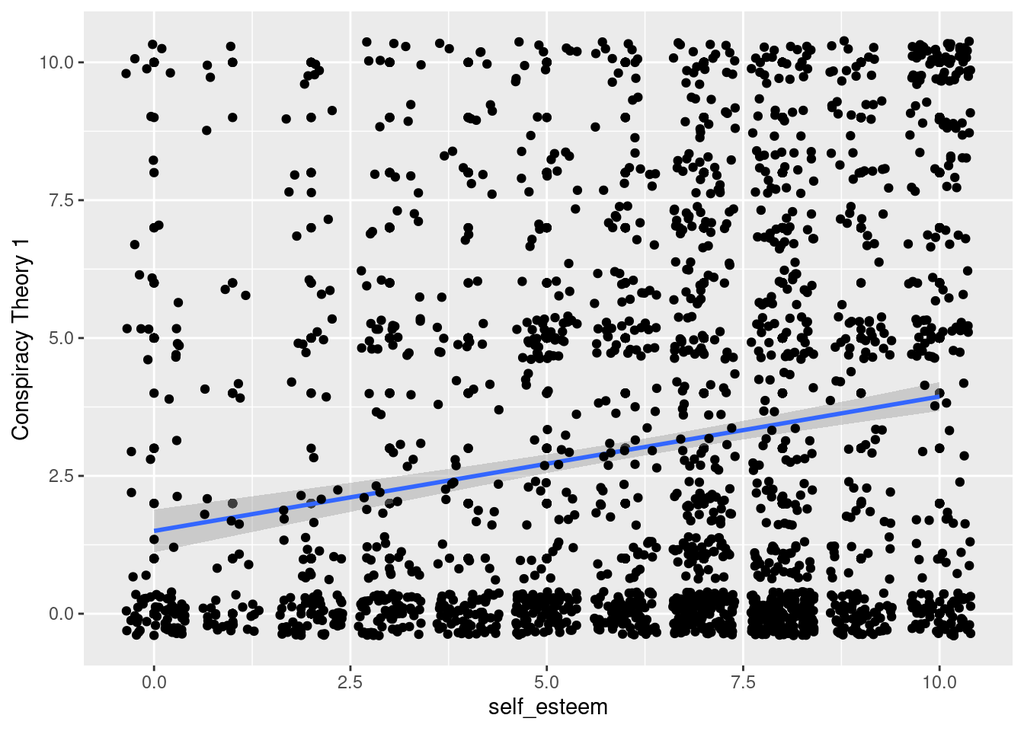

```r
icsmp_br_analise  %>%
  ggplot(aes(y=ctheory1, x=self_esteem)) + geom_point() + geom_smooth(method= "lm") +
  geom_jitter()  +
  ylab("Conspiracy Theory 1") + xlab("self_esteem")
```

## rodando regressão

```r
polrToOrdScale = function( polrObject ) {
  polrThresh = polrObject$zeta
  polrSlopes = polrObject$coefficients
  polrInter = 0.0
  polrSigma = 1.0
  K = length(polrThresh) + 1  # K is number of ordinal levels
  sigmaMult = unname( (K-2)/(polrThresh[K-1]-polrThresh[1]) )
  inter = unname( 1.5 - ( sigmaMult*polrThresh[1] ) )
  respThresh = sigmaMult*polrThresh + inter
  respSigma = sigmaMult*polrSigma
  respB0 = sigmaMult*polrInter + inter
  respSlopes = sigmaMult*polrSlopes
  return( list( sigma=respSigma ,
                b0=respB0 ,
                coefficients=respSlopes ,
                zeta=respThresh ) )
}

icsmp_br_analise_reg <- icsmp_br_analise %>%
  mutate(ctheory1 = factor(ctheory1 +1, ordered=T)) #coloca a primeira categoria como 1, para a reparametrização


m1 <- bayespolr(ctheory1 ~ nar_tra_avg + col_nar_avg + sex1 + political_ideology + self_esteem + soc_bel_avg + slf_ladder,
          data = icsmp_br_analise_reg, method = "probit")
summary(m1)
```

```
## Call:
## bayespolr(formula = ctheory1 ~ nar_tra_avg + col_nar_avg + sex1 +
##     political_ideology + self_esteem + soc_bel_avg + slf_ladder,
##     data = icsmp_br_analise_reg, method = "probit")
##
## Coefficients:
##                       Value Std. Error t value
## nar_tra_avg         0.06150    0.01468  4.1886
## col_nar_avg         0.08834    0.01081  8.1700
## sex1Female          0.00990    0.05583  0.1773
## sex1Other           0.32276    0.33973  0.9501
## political_ideology  0.21543    0.01240 17.3783
## self_esteem         0.04949    0.01212  4.0848
## soc_bel_avg        -0.07227    0.01654 -4.3701
## slf_ladder         -0.01552    0.01481 -1.0480
##
## Intercepts:
##       Value   Std. Error t value
## 1|2    1.1333  0.1427     7.9433
## 2|3    1.4199  0.1433     9.9096
## 3|4    1.6191  0.1439    11.2525
## 4|5    1.7305  0.1443    11.9962
## 5|6    1.8265  0.1446    12.6292
## 6|7    2.2230  0.1468    15.1460
## 7|8    2.3916  0.1480    16.1604
## 8|9    2.5959  0.1497    17.3448
## 9|10   2.8708  0.1523    18.8454
## 10|11  3.1335  0.1554    20.1653
##
## Residual Deviance: 6320.30
## AIC: 6356.30
## (205 observations deleted due to missingness)
```

```r
# reparametrização

m1_reparam <- polrToOrdScale( m1 )
print(m1_reparam)
```

```
## $sigma
## [1] 4.499667
##
## $b0
## [1] -3.599563
##
## $coefficients
##        nar_tra_avg        col_nar_avg         sex1Female          sex1Other
##         0.27674315         0.39749537         0.04454622         1.45229995
## political_ideology        self_esteem        soc_bel_avg         slf_ladder
##         0.96935440         0.22271051        -0.32517379        -0.06981845
##
## $zeta
##       1|2       2|3       3|4       4|5       5|6       6|7       7|8       8|9
##  1.500000  2.789707  3.686043  4.187331  4.618861  6.403128  7.162049  8.080939
##      9|10     10|11
##  9.318159 10.500000
```

```r
# source("/home/mgaldino/Documentos/Pessoal/Neuroscience/Covid-19/neuro-covid-19/Scripts/polrToOrdScale.R")
# reg_probit_reparam <- polrToOrdScale( reg_probit1 )
# print( reg_probit_reparam )
# Referências
```

Douglas, K. M., Sutton, R. M., & Cichocka, A. (2017). The psychology of conspiracy theories. Current directions in psychological science, 26(6), 538-542.

Gligorić, V., da Silva, M. M., Eker, S., van Hoek, N., Nieuwenhuijzen, E., Popova, U., & Zeighami, G. (2021). The usual suspects: How psychological motives and thinking styles predict the endorsement of well‐known and COVID‐19 conspiracy beliefs. Applied Cognitive Psychology.

Liddell, T. M., & Kruschke, J. K. (2018). Analyzing ordinal data with metric models: What could possibly go wrong?. Journal of Experimental Social Psychology, 79, 328-348.